# Random Forest & Boruta – Hands-on

Prof. Dario Gregori – Dott. Corrado Lanera

# Outline

- Preamble
  - Aims
  - Packages
  - Functions
  - Data used
- Improved tree-like models
  - Random Forests
  - Boruta
  - caret
- Supplementary materials
- Links

# Preamble

## Aims

Main aim of this hands-on are:

1. Highlight functionality of improved tree-like MLTs
2. Show packages and functions that implement in R the MLTs described:
   - `randoForest`
   - `Boruta`
   - `caret`
3. Provide some examples of use those functions (with some warnings)

To achieve these objectives, we analyze the same data used for the Hands-On CART, i.e. the median health cost levels per neighborhoods in California. Data includes geographical information (Longitude and Latitude) and administrative data (number of households, number of doctors, the percent of chronic patients and the median income of each neighborhood.

## Packages

```r
if (!requireNamespace('pacman')) {
    install.packages('pacman', dependencies = TRUE)
}
pacman::p_load(
    randomForest,
    Boruta,
    caret,
    tidyverse
)
```

### `randomForest`

The `randomForest` package implement the original Breiman and Cutler’s Random Forests for Classification and Regression and it used their original FORTRAN code, imported in R by Andy Liaw and Matthew Wiener

```r
citation('randomForest')
```

```
  A. Liaw and M. Wiener (2002). Classification and Regression
  by randomForest. R News 2(3), 18--22.

A BibTeX entry for LaTeX users is

  @Article{,
    title = {Classification and Regression by randomForest},
    author = {Andy Liaw and Matthew Wiener},
    journal = {R News},
    year = {2002},
    volume = {2},
    number = {3},
    pages = {18-22},
    url = {https://CRAN.R-project.org/doc/Rnews/},
  }
```

### `Boruta`

The aim of the package `Boruta` is to provide an interface to the algorithm for all relevant feature selection.

```r
citation('Boruta')
```

```
  Miron B. Kursa, Witold R. Rudnicki (2010). Feature
  Selection with the Boruta Package. Journal of Statistical
  Software, 36(11), 1-13. URL
  http://www.jstatsoft.org/v36/i11/.

A BibTeX entry for LaTeX users is

  @Article{,
    title = {Feature Selection with the {Boruta} Package},
    author = {Miron B. Kursa and Witold R. Rudnicki},
    journal = {Journal of Statistical Software},
    year = {2010},
    volume = {36},
    number = {11},
    pages = {1--13},
    url = {http://www.jstatsoft.org/v36/i11/},
  }
```

## Functions

### `randomForest()`

```r
?randomForest::randomForest
```

```
randomForest(x,       # data frame/matrix of predictors,
                      # or `formula, data, subset`, describing the model

    y          = NULL,                 # response vector.
                                       # If a factor --> classification,
                                       # If omitted  --> unsupervised,
                                       # otherwise   --> regression.

    xtest      = NULL,                        # test predictors (like x)

    ytest      = NULL                        # response for the test set

    ntree      = 500,                          # Number of trees to grow

     ## Number of variables randomly sampled as candidates at each split
    mtry       = if (!is.null(y) && !is.factor(y)) {    # for regression
                    max(floor(ncol(x)/3), 1)
                } else {                            # for classification
                    floor(sqrt(ncol(x)))
                },

    classwt    = NULL    # Priors of the classes. Ignored for regression

    importance = FALSE    # Should importance of predictors be assessed?
                          # (diﬀerence in prediction accuracy caused by
                          # the permutation)

    do.trace   = FALSE   # If set to TRUE, give a more verbose output as
                         # randomForest is run. If set to some integer,
                         # then running output is printed for every
                         # do.trace trees

    [...],
    ...
)
```

### `Boruta()`

```r
?Boruta::Boruta
```

```
Boruta(x,                                         # data frame of predictors

    y,                                 # response vector;
                                       #     factor  --> classification,
                                       #     numeric --> regression

    pValue  = 0.01,                                   # confidence level

    mcAdj   = TRUE,                       #  multiple testing adjustment

    maxRuns = 100,            # maximal number of importance source runs

    [...],

    ...
)
```

## Data used

```r
load(file.path('health_data'))
identical(health_data$Latitude, health_data$Lat)
```

```
[1] TRUE
```

```r
identical(health_data$Longitude, health_data$Long)
```

```
[1] TRUE
```

```r
health_data <- health_data %>%
    dplyr::select(-Latitude, -Longitude) %>%
    mutate(high_cost = (health_cost > quantile(health_cost, 0.8)) %>%
               factor(levels = c(TRUE, FALSE))
    ) %>%
    dplyr::select(-health_cost)
health_data
```

| Households | doctors | perc_chronical | income | Long | Lat | high_cost |
| --- | --- | --- | --- | --- | --- | --- |
| 436 | 17 | 0.0043929564 | 1.7823 | -117.88 | 33.76 | FALSE |
| 557 | 22 | 0.0037604291 | 3.1250 | -117.62 | 34.08 | FALSE |
| 341 | 36 | 0.0033017078 | 1.8319 | -118.99 | 35.39 | FALSE |
| 199 | 36 | 0.0021956522 | 3.7279 | -118.05 | 34.05 | FALSE |
| 565 | 27 | 0.0044600939 | 3.5652 | -121.95 | 37.31 | TRUE |
| 324 | 25 | 0.0030145719 | 3.6250 | -117.70 | 34.09 | FALSE |
| 754 | 28 | 0.0054502688 | 3.6429 | -121.91 | 37.31 | TRUE |
| 1054 | 20 | 0.0031751825 | 7.1670 | -118.59 | 34.26 | TRUE |
| 12 | 46 | 0.0036666667 | 2.3750 | -122.42 | 37.63 | FALSE |
| 1037 | 15 | 0.0031383577 | 3.0466 | -121.85 | 37.36 | FALSE |

[output cut: 990 more lines]

# Improved tree-like models

```r
train_idx <- createDataPartition(health_data$high_cost,
                p = 0.8, list = FALSE
)
(train_set <- health_data[train_idx, ])
```

|  | Households | doctors | perc_chronical | income | Long | Lat | high_cost |
| --- | --- | --- | --- | --- | --- | --- | --- |
| 3 | 341 | 36 | 0.0033017078 | 1.8319 | -118.99 | 35.39 | FALSE |
| 4 | 199 | 36 | 0.0021956522 | 3.7279 | -118.05 | 34.05 | FALSE |
| 5 | 565 | 27 | 0.0044600939 | 3.5652 | -121.95 | 37.31 | TRUE |
| 6 | 324 | 25 | 0.0030145719 | 3.6250 | -117.70 | 34.09 | FALSE |
| 7 | 754 | 28 | 0.0054502688 | 3.6429 | -121.91 | 37.31 | TRUE |
| 8 | 1054 | 20 | 0.0031751825 | 7.1670 | -118.59 | 34.26 | TRUE |
| 9 | 12 | 46 | 0.0036666667 | 2.3750 | -122.42 | 37.63 | FALSE |
| 10 | 1037 | 15 | 0.0031383577 | 3.0466 | -121.85 | 37.36 | FALSE |
| 11 | 283 | 32 | 0.0035257985 | 15.0001 | -122.22 | 37.40 | TRUE |
| 12 | 136 | 24 | 0.0052012384 | 3.5000 | -118.93 | 34.82 | FALSE |

[output cut: 990 more lines]

```r
(test_set  <- health_data[-train_idx, ])
```

|  | Households | doctors | perc_chronical | income | Long | Lat | high_cost |
| --- | --- | --- | --- | --- | --- | --- | --- |
| 1 | 436 | 17 | 0.0043929564 | 1.7823 | -117.88 | 33.76 | FALSE |
| 2 | 557 | 22 | 0.0037604291 | 3.1250 | -117.62 | 34.08 | FALSE |
| 15 | 632 | 36 | 0.0019348498 | 2.0972 | -121.88 | 37.33 | FALSE |
| 17 | 781 | 17 | 0.0036305461 | 3.7175 | -116.94 | 33.73 | FALSE |
| 22 | 993 | 18 | 0.0035669213 | 10.7372 | -122.00 | 37.86 | TRUE |
| 25 | 506 | 26 | 0.0026717557 | 2.8106 | -118.30 | 33.82 | FALSE |
| 30 | 14 | 33 | 0.0059574468 | 0.5360 | -121.31 | 37.44 | FALSE |
| 33 | 403 | 52 | 0.0038737041 | 6.3434 | -122.23 | 37.85 | TRUE |
| 35 | 458 | 5 | 0.0035387962 | 3.7917 | -117.53 | 34.10 | FALSE |
| 49 | 318 | 33 | 0.0022439353 | 4.3527 | -118.27 | 33.86 | FALSE |

[output cut: 990 more lines]

## Random forests

```r
rf_model <- randomForest(
    x           = train_set %>% dplyr::select(-high_cost),
    y           = train_set[['high_cost']],
    ntree       = 100,
    xtest       = test_set %>% dplyr::select(-high_cost),
    ytest       = test_set[['high_cost']],
    importance  = TRUE,
    keep.forest = TRUE,
    do.trace    = 10
)
```

```
ntree      OOB      1      2|    Test      1      2
   10:   9.96% 26.35%  5.86%|   8.24% 25.15%  4.01%
   20:   8.80% 26.55%  4.36%|   8.29% 26.62%  3.71%
   30:   8.38% 26.36%  3.88%|   8.26% 26.91%  3.60%
   40:   8.15% 26.47%  3.58%|   8.21% 27.06%  3.49%
   50:   8.14% 26.43%  3.57%|   8.03% 26.47%  3.42%
   60:   7.92% 25.92%  3.42%|   8.21% 27.21%  3.46%
   70:   8.08% 26.14%  3.57%|   8.00% 26.32%  3.42%
   80:   8.01% 25.99%  3.52%|   7.94% 26.62%  3.27%
   90:   7.93% 26.03%  3.41%|   8.00% 26.76%  3.31%
  100:   7.86% 25.77%  3.38%|   7.82% 25.88%  3.31%
```

```r
rf_model
```

```
Call:
 randomForest(x = train_set %>% dplyr::select(-high_cost), y = train_set[["high_cost"]],      xtest = test_set %>% dplyr::select(-high_cost), ytest = test_set[["high_cost"]],      ntree = 100, importance = TRUE, do.trace = 10, keep.forest = TRUE)
               Type of random forest: classification
                     Number of trees: 100
No. of variables tried at each split: 2

        OOB estimate of  error rate: 7.86%
Confusion matrix:
      TRUE FALSE class.error
TRUE  2019   701  0.25772059
FALSE  368 10512  0.03382353
                Test set error rate: 7.82%
Confusion matrix:
      TRUE FALSE class.error
TRUE   504   176  0.25882353
FALSE   90  2630  0.03308824
```

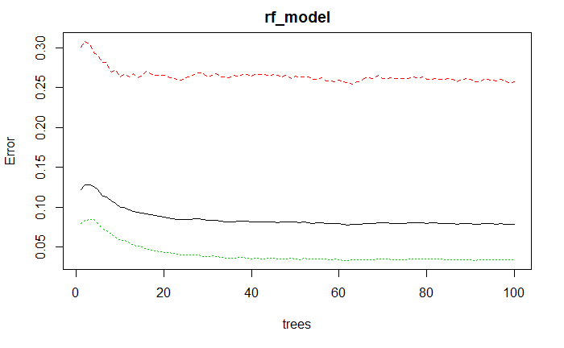

```r
plot(rf_model)                           # ?randomForest:::plot.randomForest
```

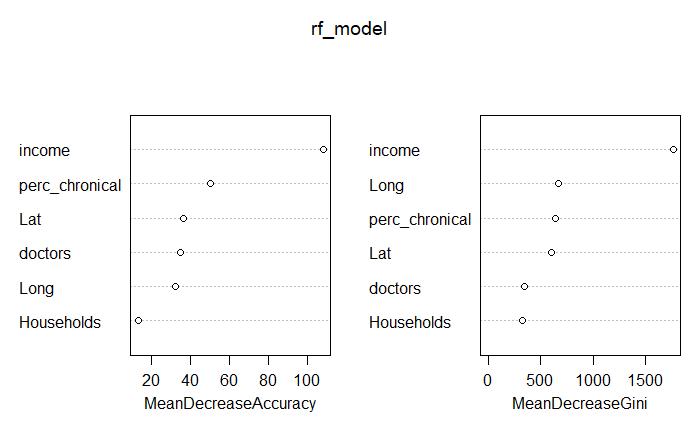

```r
varImpPlot(rf_model)                                           # ?varImpPlot
```

```r
rf_model %>% names
```

```
 [1] "call"            "type"            "predicted"
 [4] "err.rate"        "confusion"       "votes"
 [7] "oob.times"       "classes"         "importance"
[10] "importanceSD"    "localImportance" "proximity"
[13] "ntree"           "mtry"            "forest"
[16] "y"               "test"            "inbag"
```

```r
train_stats <- caret::confusionMatrix(
    predict(rf_model, train_set %>% dplyr::select(-high_cost)),
    train_set[['high_cost']]
)
train_stats
```

```
Confusion Matrix and Statistics

          Reference
Prediction  TRUE FALSE
     TRUE   2720     0
     FALSE     0 10880

               Accuracy : 1
                 95% CI : (0.9997, 1)
    No Information Rate : 0.8
    P-Value [Acc > NIR] : < 2.2e-16

                  Kappa : 1
 Mcnemar's Test P-Value : NA

            Sensitivity : 1.0
            Specificity : 1.0
         Pos Pred Value : 1.0
         Neg Pred Value : 1.0
             Prevalence : 0.2
         Detection Rate : 0.2
   Detection Prevalence : 0.2
      Balanced Accuracy : 1.0

       'Positive' Class : TRUE
```

```r
test_stats <- caret::confusionMatrix(
    predict(rf_model, test_set %>% dplyr::select(-high_cost)),
    test_set[['high_cost']]
)
test_stats
```

```
Confusion Matrix and Statistics

          Reference
Prediction TRUE FALSE
     TRUE   504    91
     FALSE  176  2629

               Accuracy : 0.9215
                 95% CI : (0.9119, 0.9303)
    No Information Rate : 0.8
    P-Value [Acc > NIR] : < 2.2e-16

                  Kappa : 0.7425
 Mcnemar's Test P-Value : 2.737e-07

            Sensitivity : 0.7412
            Specificity : 0.9665
         Pos Pred Value : 0.8471
         Neg Pred Value : 0.9373
             Prevalence : 0.2000
         Detection Rate : 0.1482
   Detection Prevalence : 0.1750
      Balanced Accuracy : 0.8539

       'Positive' Class : TRUE
```

## Boruta

```r
system.time(
    boruta_varimp <- Boruta(
        x       = train_set %>% dplyr::select(-high_cost),
        y       = train_set[['high_cost']]
    )
)
```

```
   user  system elapsed
 199.15    0.99   36.31
```

```r
boruta_varimp
```

```
Boruta performed 10 iterations in 36.29709 secs.
 6 attributes confirmed important: doctors, Households,
income, Lat, Long and 1 more;
 No attributes deemed unimportant.
```

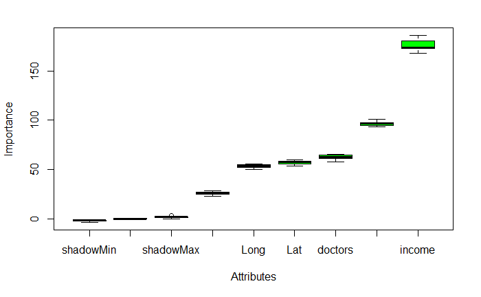

```r
plot(boruta_varimp)
```

```r
load('train_fake.rda')
train_fake
```

|  | Households | doctors | perc_chronical | income | Long | Lat | high_cost | X1 | X2 | X3 |
| --- | --- | --- | --- | --- | --- | --- | --- | --- | --- | --- |
| 1 | 436 | 17 | 0.0043929564 | 1.7823 | -117.88 | 33.76 | FALSE | 90.91942 | 38.92269 | 91.9218270 |
| 2 | 557 | 22 | 0.0037604291 | 3.1250 | -117.62 | 34.08 | FALSE | 80.50912 | 32.76757 | 63.7856461 |
| 4 | 199 | 36 | 0.0021956522 | 3.7279 | -118.05 | 34.05 | FALSE | 76.44062 | 30.40937 | -12.4891179 |
| 5 | 565 | 27 | 0.0044600939 | 3.5652 | -121.95 | 37.31 | TRUE | 65.37082 | 32.10291 | -66.2145276 |
| 6 | 324 | 25 | 0.0030145719 | 3.6250 | -117.70 | 34.09 | FALSE | 51.43164 | 25.06120 | -70.0017000 |
| 7 | 754 | 28 | 0.0054502688 | 3.6429 | -121.91 | 37.31 | TRUE | 84.07509 | 35.06445 | -4.3238167 |
| 8 | 1054 | 20 | 0.0031751825 | 7.1670 | -118.59 | 34.26 | TRUE | 83.98091 | 47.83300 | -69.9578987 |
| 9 | 12 | 46 | 0.0036666667 | 2.3750 | -122.42 | 37.63 | FALSE | 67.64838 | 28.68344 | 0.6390531 |
| 10 | 1037 | 15 | 0.0031383577 | 3.0466 | -121.85 | 37.36 | FALSE | 72.40854 | 47.27023 | 66.4298398 |
| 13 | 363 | 52 | 0.0032570423 | 4.3125 | -122.42 | 37.74 | FALSE | 83.38039 | 43.30929 | -20.1994232 |

[output cut: 990 more lines]

```r
system.time(
    boruta_fake_imp <- Boruta(
        x       = train_fake %>% dplyr::select(-high_cost),
        y       = train_fake[['high_cost']]
    )
)
```

```
   user  system elapsed
 952.33    2.22  136.83
```

```r
boruta_fake_imp
```

```
Boruta performed 30 iterations in 2.280374 mins.
 7 attributes confirmed important: doctors, Households,
income, Lat, Long and 2 more;
 2 attributes confirmed unimportant: X1, X2;
```

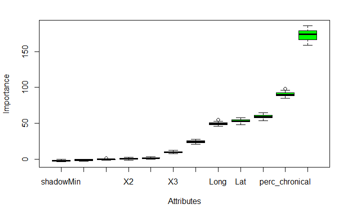

```r
plot(boruta_fake_imp)
```

## Caret

```r
system.time(
    caret_rf <- caret::train(form = high_cost ~ .,
            data       = train_set,
            trControl  = trainControl(
                method = "cv",
                number = 5
            ),
            method     = "rf",
            tuneLength = 5,         # only mtry. (ntree = 500 is fixed!)
            do.trace    = 100
    )
)
```

```
ntree      OOB      1      2
  100:   8.31% 27.94%  3.40%
  200:   8.20% 27.71%  3.32%
  300:   8.15% 27.53%  3.31%
  400:   8.11% 27.39%  3.29%
  500:   8.01% 27.07%  3.25%
ntree      OOB      1      2
  100:   8.26% 27.25%  3.52%
  200:   8.07% 27.02%  3.33%
  300:   8.15% 27.30%  3.37%
  400:   8.07% 27.02%  3.33%
  500:   8.18% 27.39%  3.38%
ntree      OOB      1      2
  100:   8.52% 28.40%  3.55%
  200:   8.58% 28.49%  3.60%
```

[output cut: 143 more lines]

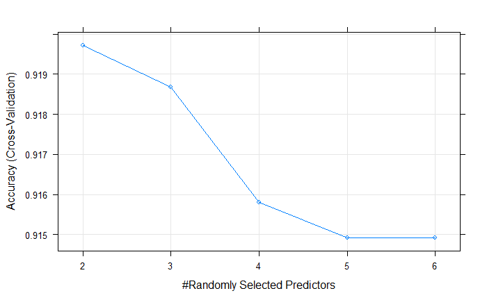

```r
plot(caret_rf)
```

```r
caret_rf
```

```
Random Forest

13600 samples
    6 predictor
    2 classes: 'TRUE', 'FALSE'

No pre-processing
Resampling: Cross-Validated (5 fold)
Summary of sample sizes: 10880, 10880, 10880, 10880, 10880
Resampling results across tuning parameters:

  mtry  Accuracy   Kappa
  2     0.9197059  0.7354315
  3     0.9186765  0.7324269
  4     0.9158088  0.7224743
  5     0.9149265  0.7196325
  6     0.9149265  0.7201108

Accuracy was used to select the optimal model using the
 largest value.
The final value used for the model was mtry = 2.
```

```r
caret_rf$finalModel
```

```
Call:
 randomForest(x = x, y = y, mtry = param$mtry, do.trace = 100)
               Type of random forest: classification
                     Number of trees: 500
No. of variables tried at each split: 2

        OOB estimate of  error rate: 8%
Confusion matrix:
      TRUE FALSE class.error
TRUE  1993   727  0.26727941
FALSE  361 10519  0.03318015
```

### Boruta (optional)

Note: the Boruta method is now deprecated with the current version of `caret`. We can retrieve its original code from the `caret` GitHub repository at https://github.com/topepo/caret/blob/master/models/deprecated/Boruta.R.

To use it we have to run the code and store the results in an object we will call as the “method” of in the `train()` call.

```r
Boruta <- list(
    label      = "Random Forest with Additional Feature Selection",

    library    = c("Boruta", "randomForest"),

    type       = c("Regression", "Classification"),

    parameters = data.frame(
        parameter = c('mtry'),
        class     = c("numeric"),
        label     = c("#Randomly Selected Predictors")
    ),

    grid  = function(x, y, len = NULL, search = "grid") {
        if (search == "grid") {
            out <- data.frame(mtry = caret::var_seq(
                p = ncol(x),
                classification = is.factor(y),
                len = len
            ))
        } else {
            out <- data.frame(
                mtry = unique(sample(1:ncol(x),
                    replace = TRUE,
                    size    = len
                ))
            )
        }
        out
    },

    loop = NULL,

    fit  = function(x, y, wts, param, lev, last, classProbs, ...) {
        fs <- Boruta(x, y, mtry = param$mtry, ...)
        keepers <- as.character(
            names(fs$finalDecision)[fs$finalDecision == "Confirmed"]
        )
        out <- randomForest(x[, keepers, drop = FALSE], y,
            mtry = param$mtry, ...
        )
        out$Boruta <- fs
        out
    },

    predict = function(modelFit, newdata, submodels = NULL) {
        predict(modelFit, newdata)
    },

    prob    = function(modelFit, newdata, submodels = NULL) {
        predict(modelFit, newdata, type = "prob")
    },

    tags = c(
        "Tree-Based Model",
        "Ensemble Model",
        "Feature Selection Wrapper",
        "Random Forest"
    ),

    levels = function(x) x$classes,

    sort   = function(x) x[order(x[, 1]), ]
)
```

Now, we can use the method calling it (without the quotes because we are telling to `caret` which object it has to use to train the model and we are not asking it to retreive the method with the provided name!)

```r
system.time(
    caret::train(form = high_cost ~ .,
            data      = train_fake,
            trControl = trainControl(
                method = "cv",
                number = 5
            ),
            method    = Boruta,
            tuneLength = 5          # only mtry. (ntree = 500 is fixed!)
    )
)
```

```
invalid mtry: reset to within valid rangeinvalid mtry: reset to within valid rangeinvalid mtry: reset to within valid rangeinvalid mtry: reset to within valid rangeinvalid mtry: reset to within valid range
```

```
    user   system  elapsed
14395.17    31.75  2134.75
```

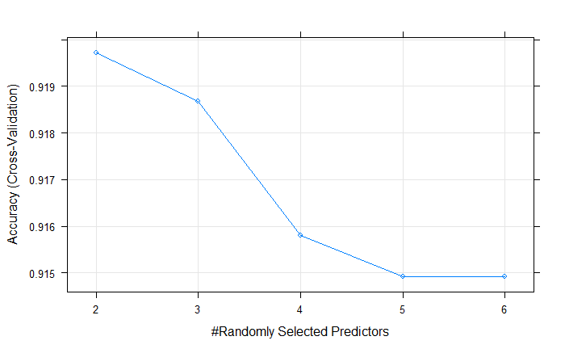

```r
plot(caret_rf)
```

```r
caret_rf
```

```
Random Forest

13600 samples
    6 predictor
    2 classes: 'TRUE', 'FALSE'

No pre-processing
Resampling: Cross-Validated (5 fold)
Summary of sample sizes: 10880, 10880, 10880, 10880, 10880
Resampling results across tuning parameters:

  mtry  Accuracy   Kappa
  2     0.9197059  0.7354315
  3     0.9186765  0.7324269
  4     0.9158088  0.7224743
  5     0.9149265  0.7196325
  6     0.9149265  0.7201108

Accuracy was used to select the optimal model using the
 largest value.
The final value used for the model was mtry = 2.
```

```r
caret_rf$finalModel
```

```
Call:
 randomForest(x = x, y = y, mtry = param$mtry, do.trace = 100)
               Type of random forest: classification
                     Number of trees: 500
No. of variables tried at each split: 2

        OOB estimate of  error rate: 8%
Confusion matrix:
      TRUE FALSE class.error
TRUE  1993   727  0.26727941
FALSE  361 10519  0.03318015
```

# Supplementary materials

```r
set.seed(4)

train_fake <- train_set %>%
    mutate(
        X1 = rnorm(nrow(train_set), 70, 8) + 7,
        X2 = runif(nrow(train_set), 23, 57) +
             3 * rnorm(nrow(train_set), 0, 0.1),
        X3 = rnorm(nrow(train_set), 10, 67) + train_set$income^2
    )

# save(train_set,file = "train_fake.Rda")
```

# Links

- R help: `?`